# t-Tests

## Q3.

1. Match the t-test with the null/alternative hypothesis
   - Done.
2. Which t Test requires that the sampling distribution of the sample mean of the differences is normally distributed?
   - Paired Samples t Test

3.Use a subset of the CO2 dataset in R to answer the following questions. Filter the dataset so that you are considering only the chilled plants where conc = 250. (Hint: Treatment == “chilled” & conc == 250) > ?CO2 > View(CO2)

3.1 **What are the mean uptake values for each Type of plant (Quebec and Mississippi) for plants that are chilled at a concentration of 250?**

```r
# Standardize dataset name
df <- CO2

# Filter dataset
CO2.chilled.250 <- filter(df, Treatment == "chilled" & conc == 250)

# Standardize and abbreviate species names
Types <- unique(CO2.chilled.250$Type)

# Loop to get the mean uptake for each unique type of plant
for (t in Types) {
  result <- round(mean(filter(CO2.chilled.250, Type == t)$uptake),2)
  print(paste(t, "mean uptake:", result))
}
```

```
## [1] "Quebec mean uptake: 34.47"
## [1] "Mississippi mean uptake: 16.1"
```

3.2 **Recreate one of these dot plots in R using either Base or ggplot2 graphics.**

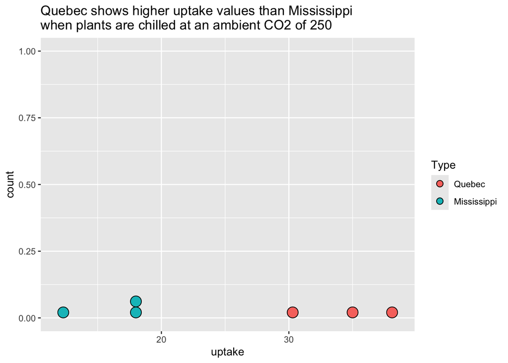

```r
(
  ggplot(CO2.chilled.250, aes(x = uptake, fill = Type))
    + geom_dotplot(color="black")
    + labs(
      title = "Quebec shows higher uptake values than Mississippi \nwhen plants are chilled at an ambient CO2 of 250",
    )
)
```

3.3 **Report the test statistic, the parametric distribution being used for the test statistic (including degrees of freedom if appropriate), and p-value of the test.**
$$H_0: \mu_{Miss} - \mu_{Queb} = 0$$
$$H_a: \mu_{Miss} - \mu_{Queb} \neq 0$$

```r
# Plant types
types <- c("Quebec", "Mississippi")

# Subset the data by type
Quebec <- CO2.chilled.250$uptake[CO2.chilled.250$Type == types[1]]
Mississippi <- CO2.chilled.250$uptake[CO2.chilled.250$Type == types[2]]

# t test (independent samples)
output <- t.test(Quebec, Mississippi, mu = 0, alternative = "two.sided", conf.level = 0.95)

# Normal output
cat("Original output:")
```

```
## Original output:
```

```r
output
```

```
##
##  Welch Two Sample t-test
##
## data:  Quebec and Mississippi
## t = 6.2075, df = 3.8818, p-value = 0.003782
## alternative hypothesis: true difference in means is not equal to 0
## 95 percent confidence interval:
##  10.05213 26.68120
## sample estimates:
## mean of x mean of y
##  34.46667  16.10000
```

```r
# Clean output
cat("Clean output:")
```

```
## Clean output:
```

```r
pander(output)
```

Welch Two Sample t-test: `Quebec` and `Mississippi` (continued below)

| Test statistic | df | P value | Alternative hypothesis | mean of x |
| --- | --- | --- | --- | --- |
| 6.207 | 3.882 | 0.003782 * * | two.sided | 34.47 |

| mean of y |
| --- |
| 16.1 |

3.4 **How many plants of each Type (Mississippi and Quebec) are in the sample of data?**

```r
CO2.chilled.250 %>%
  count(Type)
```

```
##          Type n
## 1      Quebec 3
## 2 Mississippi 3
```

3.5

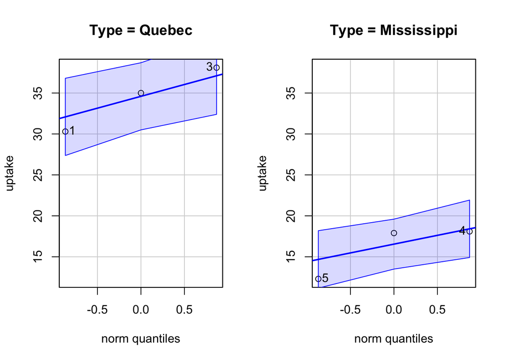

```r
# qqplots for both subsets
qqPlot(uptake ~ Type, data = CO2.chilled.250)
```